# R Notebook

# Purpose of Script:

# Part 1: Cluster and ID noto cells at each timepoint: 8, 10, 14, 18.

# Note: We already have 24hpf information from gencomp/zeb_integrated_50/mod.zeb.cell.type.list.

# It is batch-corrected unlike the matrices of other timepoints.

# Part 2: Get Noto Cells and Data Matrices. Noto cell ID is validated against wagner_degs.

# Part 3: Export intersection of zeb_genes as “all_zeb_notoXnoto_genes.csv”

# zeb_8hpf_dir -> zeb_8_hpf_df -> zeb_8hpf_seurat -> zeb_8hpf_noto_cells, zeb_8hpf_noto_mat (contains data from @assays$RNA@data)

# all_zeb_notoXnoto_gene_list = list(zeb_8hpf_noto_mat) -> all_zeb_notoXnoto_genes (24155) -> “all_zeb_notoXnoto_genes.csv”

# 24hpf noto matrices were extracted from ~/princeton_google_drive/Levine Lab/R_Environments/Orthology-Maps_R_Environments/orthology_map_batch_correction

# THERE WAS AN ISSUE WITH ZEB_8/18HPF_NOTO_MATS! Fixed 12/3/20.

PART 1

```
    ############ Cluster and ID Noto Cells ############
```

```r
parent_dir <- "/home/pprakriti/princeton_google_drive/Levine Lab/Orthology-Maps/Raw_Data/Klein_2018/"
```

```r
zeb_10hpf_dir <- "/home/pprakriti/princeton_google_drive/Levine Lab/Orthology-Maps/Raw_Data/Klein_2018/GSM3067192_10hpf.csv"
# 4281
zeb_10hpf_df <- read.table(zeb_10hpf_dir,
                          sep = ",",
                          header = TRUE,
                          stringsAsFactors = FALSE)

zeb_14hpf_dir <- "/home/pprakriti/princeton_google_drive/Levine Lab/Orthology-Maps/Raw_Data/Klein_2018/GSM3067193_14hpf.csv"
# 4002
zeb_14hpf_df <- read.table(zeb_14hpf_dir,
                          sep = ",",
                          header = TRUE,
                          stringsAsFactors = FALSE)

zeb_18hpf_dir <- "/home/pprakriti/princeton_google_drive/Levine Lab/Orthology-Maps/Raw_Data/Klein_2018/GSM3067194_18hpf.csv"
# 6963
zeb_18hpf_df <- read.table(zeb_18hpf_dir,
                          sep = ",",
                          header = TRUE,
                          stringsAsFactors = FALSE)
```

""" Start Aside: Let’s munge these dataframes s.t. Rownames are genes and Colnames are only cells. """

```r
rownames(zeb_8hpf_df) <- zeb_8hpf_df$Row
zeb_8hpf_df$Row <- NULL
```

# Helper Function

```r
clean_df <- function(zeb_df) {
  rownames(zeb_df) <- zeb_df$Row
  zeb_df$Row <- NULL
  clean_zeb_df <- zeb_df
  return(clean_zeb_df)
}
```

```r
zeb_10hpf_df <- clean_df(zeb_10hpf_df)
zeb_14hpf_df <- clean_df(zeb_14hpf_df)
zeb_18hpf_df <- clean_df(zeb_18hpf_df)
```

""" End Aside: Let’s munge these dataframes s.t. Rownames are genes and Colnames are only cells. """

CLUSTER

""" Make Seurats -> FindNeighbors """ # Helper Function

```r
make_zeb_seurat <- function(zeb_df, min_cells, min_features, n_features, zeb_pca_dims) {
  zeb_seurat <- CreateSeuratObject(counts = zeb_df,
                                   min.cells = min_cells,
                                   min.features = min_features)

  zeb_seurat <- NormalizeData(object = zeb_seurat)

  zeb_seurat <- FindVariableFeatures(zeb_seurat,
                                     selection.method = "vst",
                                     nfeatures = n_features)
  zeb_seurat <- ScaleData(object = zeb_seurat)

  zeb_seurat <- RunPCA(zeb_seurat, dims = 1:zeb_pca_dims)

  zeb_seurat <- FindNeighbors(zeb_seurat, dims = 1:zeb_pca_dims)

  return(zeb_seurat)
}
```

""" Make all of the Seurat Objects """ # (1) 8hpf

```r
zeb_8hpf_seurat <- make_zeb_seurat(zeb_8hpf_df, 3, 200, 2000, 20)
```

[output not shown]

```r
zeb_10hpf_seurat <- make_zeb_seurat(zeb_10hpf_df, 3, 200, 2000, 20)
zeb_14hpf_seurat <- make_zeb_seurat(zeb_14hpf_df, 3, 200, 2000, 20)
```

```r
zeb_18hpf_seurat <- make_zeb_seurat(zeb_18hpf_df, 3, 200, 2000, 20)
```

""" List of DEGs """

```r
wagner_deg_csv <- "/home/pprakriti/princeton_google_drive/Levine Lab/Orthology-Maps/Papers/Methods/wagner_klein_supp/wagner_klein_TableS2_csv.csv"

wagner_deg_df <- read.table(wagner_deg_csv,
           sep = ",",
           header = FALSE,
           stringsAsFactors = FALSE)
```

# Let’s munge this df a little bit.

```r
add_mast_id <- function(num, flag) {
  mast_id_name <- paste0(flag, num)
  return (mast_id_name)
}

nums <- 1:20
enriched_ids <- sapply(nums, FUN = add_mast_id, "enriched_")
rank_sum_ids <- sapply(nums, FUN = add_mast_id, "rank_sum_")
```

```r
colnames(wagner_deg_df) <- c("Cluster_num", "Cluster_ID", "Cluster_name", "Timepoint_hpf", "Tissue_ID", "Tissue_name", enriched_ids, "Blank", rank_sum_ids)
```

""" Get DEGs of Interest (ClusterName, Enriched/Rank Sum MAST Genes) """

# CHANGE

```r
your_cluster_name <- "08hpf-notocord"
your_start <- "enriched_1"
your_end <- "enriched_20"

wagner_df <- wagner_deg_df[wagner_deg_df$Cluster_name == your_cluster_name, ] %>%
                                      select(all_of(your_start):all_of(your_end))

# This is what will be used downstream.
wagner_degs <- unique(as.character(wagner_df))
```

""" Cluster + ID """ # CHANGE!

```r
your_seurat <- zeb_8hpf_seurat
```

# CHANGE!

```r
your_reso <- 1
```

# (1) Find Clusters

```r
your_seurat <- FindClusters(your_seurat, resolution = your_reso)
```

```
Modularity Optimizer version 1.3.0 by Ludo Waltman and Nees Jan van Eck

Number of nodes: 3568
Number of edges: 130731

Running Louvain algorithm...
```

```
Maximum modularity in 10 random starts: 0.8090
Number of communities: 14
Elapsed time: 0 seconds
```

```r
your_seurat <- RunUMAP(your_seurat, dims = 1:20)
```

```
The default method for RunUMAP has changed from calling Python UMAP via reticulate to the R-native UWOT using the cosine metric
To use Python UMAP via reticulate, set umap.method to 'umap-learn' and metric to 'correlation'
This message will be shown once per session16:56:25 UMAP embedding parameters a = 0.9922 b = 1.112
```

# (*) Visualize the Clusters

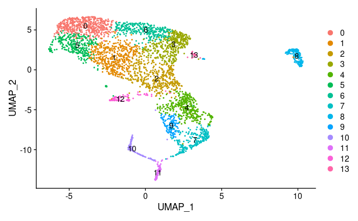

```r
DimPlot(your_seurat,
        reduction = "umap",
        label = TRUE)
```

# (2) ID Noto Cells

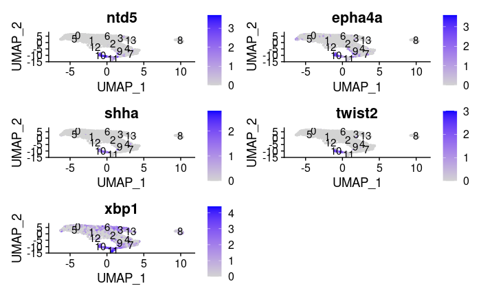

```r
FeaturePlot(object = your_seurat,
            features = wagner_degs[1:5],
            reduction = "umap",
            label = TRUE)
```

```r
test_noto <- WhichCells(your_seurat, idents = 10)
```

""" Validate Clusters Note: I am using Wilcox Test vs. Wagner MAST """ # Helper Function

```r
get_top_n_df <- function(cell_type, seurat_object, test_use, n_top) {
  # Given a cell type (output of WhichCells), get n_top DEGs using FindMarkers
  # with test of preference and custom munge_markers function
  # (ref docstring with details)
  #
  # Args and Returns: Self-explanatory
  cell_type_markers <- FindMarkers(object = seurat_object,
                                     ident.1 = cell_type,
                                     test.use = test_use)

  munged_cell_type_markers <- munge_markers(cell_type_markers)[1:n_top, ]

  return(munged_cell_type_markers)
}
```

# CHANGE!

```r
your_noto_cluster_ID <- c(10)
```

# (1) Get Noto Cells, and their DEG dfs.

```r
your_noto_cells <- WhichCells(your_seurat, idents = your_noto_cluster_ID)
your_degs_df <- get_top_n_df(your_noto_cells, your_seurat, "wilcox", 20)
```

# (2) Get common DEGs.

```r
your_degs <- rownames(your_degs_df)
common_degs <- intersect(wagner_degs, your_degs)
length(common_degs)
```

```
[1] 20
```

""" Get Data Matrices for Noto Cells """ # (1) Get Data Matrix

```r
your_mat <- your_seurat@assays$RNA@data
your_noto_mat <- your_mat[, your_noto_cells]
```

```
Error in intI(j, n = x@Dim[2], dn[[2]], give.dn = FALSE) :
  invalid character indexing
```

# 12/3: Fixed zeb_8hpf_noto_mat.

```r
mat_8hpf <- zeb_8hpf_seurat@assays$RNA@data
zeb_8hpf_noto_mat <- mat_8hpf[, zeb_8hpf_noto_cells]
```

# 12/3: Fixed zeb_18hpf_noto_mat.

```r
mat_18HPF <- zeb_18hpf_seurat@assays$RNA@data
zeb_18hpf_noto_mat <- mat_18HPF[, zeb_18hpf_noto_cells]
```

# (2) Save noto cells and noto_mat.

# CHANGE!

```r
# zeb_8hpf_noto_cells/mat
zeb_8hpf_noto_cells <- your_noto_cells
zeb_8hpf_noto_mat <- your_noto_mat
```

# (3) Delete the Seurat Object!

# (4) Finally, extract 24hpf Data Mats

```r
batch_zeb_data <- readRDS("/home/pprakriti/Desktop/orthology_map_batch_correction/vera_batch_correction/zeb/gencomp_zeb_batch_correct_dir/gencomp_zeb_batch_data.rds")
```

```r
zeb_24hpf_noto_cells <- mod.zeb.cell.type.list$noto
zeb_24hpf_noto_mat <- batch_zeb_data[, zeb_24hpf_noto_cells]
```

# (5) Get names of all zeb_genes that appear in matrices.

```r
all_zeb_notoXnoto_gene_list <- list(rownames(zeb_8hpf_noto_mat),
                                    rownames(zeb_10hpf_noto_mat),
                                    rownames(zeb_14hpf_noto_mat),
                                    rownames(zeb_18hpf_noto_mat),
                                    rownames(zeb_24hpf_noto_mat))
# 24155
all_zeb_notoXnoto_genes <- Reduce(intersect, all_zeb_notoXnoto_gene_list)
```

# Check that all matrices have these khids.

```r
check_in <- function(your_vec, to_check_vec) {
  # checks if all of "to_check_vec" is in "your_vec"
  return(all(to_check_vec %in% your_vec))
}
```

# Yes they do!

```r
sapply(X = all_zeb_notoXnoto_gene_list,
       FUN = check_in, all_zeb_notoXnoto_genes)
```

```
[1] TRUE TRUE TRUE TRUE TRUE
```

# Write out to csv.

```r
output_dir <- "/home/pprakriti/princeton_google_drive/Levine Lab/Orthology-Maps/1_CURRENT/notoXnoto/"
output_name <- "all_zeb_notoXnoto_genes.csv"

write.table(x = all_zeb_notoXnoto_genes,
          file = paste0(output_dir, output_name),
          row.names = FALSE,
          col.names = FALSE)
```